# Machine Learning - presentation

Monika Kaczan and Katarzyna Jałbrzykowska

05 June 2022

# Classification - drugs dataset

### Data preparation

Firstly, we loaded the data, checked how they look like and whether there are any missing observations. We dropped the id column.

```r
glimpse(drugs)
```

```
## Rows: 1,500
## Columns: 20
## $ age                            <chr> "45-54", "25-34", "18-24", "25-34", "18~
## $ gender                         <chr> "male", "male", "female", "female", "ma~
## $ education                      <chr> "Masters degree", "University degree", ~
## $ country                        <chr> "USA", "USA", "USA", "USA", "Australia"~
## $ ethnicity                      <chr> "Mixed-Black/Asian", "Mixed-Black/Asian~
## $ personality_neuroticism        <dbl> 57.6, 47.8, 57.6, 71.8, 56.1, 47.8, 75.~
## $ personality_extraversion       <dbl> 57.3, 67.0, 43.3, 31.2, 62.3, 20.7, 69.~
## $ personality_openness           <dbl> 50.1, 45.7, 55.3, 43.6, 70.2, 57.8, 62.~
## $ personality_agreeableness      <dbl> 47.8, 47.8, 45.6, 56.3, 66.1, 41.2, 54.~
## $ personality_conscientiousness  <dbl> 53.7, 56.0, 49.9, 31.8, 42.4, 33.6, 38.~
## $ personality_impulsiveness      <dbl> 42.8, 33.8, 63.0, 63.0, 50.4, 56.5, 56.~
## $ personality_sensation          <dbl> 22.4, 30.8, 62.0, 71.1, 62.0, 62.0, 22.~
## $ consumption_alcohol            <chr> "used in last week", "used in last week~
## $ consumption_amphetamines       <chr> "used over a decade ago", "never used",~
## $ consumption_caffeine           <chr> "used in last day", "used in last week"~
## $ consumption_cannabis           <chr> "used in last week", "never used", "use~
## $ consumption_chocolate          <chr> "used in last day", "used in last day",~
## $ consumption_mushrooms          <chr> "never used", "never used", "used in la~
## $ consumption_nicotine           <chr> "used in last week", "never used", "use~
## $ consumption_cocaine_last_month <chr> "No", "No", "No", "No", "No", "No", "Ye~
```

As ordinal and categorical variables are stored as characters, we converted them into factors. We also noticed that some categories are similar in terms of definition, or contain very few observations. This is why we decided to: - merge Canada, Ireland, UK and New Zealand to ‘Other’ in variable ‘country’ - merge 55-64 and 65+ categories for ‘age’ - merge all ‘Left school before…’ categories for ‘education’ as well as merge ‘Masters degree’ and ‘Doctorate degree’ - merge ‘never used’ and ‘used over a decade ago’ as well as ‘used in last day’ and ‘used in last week’ categories for all consumption variables. We also decided to drop variable ‘ethnicity’ because it was almost homogeneous.

```r
table(drugs$ethnicity)
```

```
##
##             Asian             Black Mixed-Black/Asian Mixed-White/Asian
##                25                22              1372                15
## Mixed-White/Black             Other             White
##                47                16                 3
```

```r
drugs <- subset(drugs, select = -c(ethnicity) )
```

We also checked relationship between the dependend variable (consumption_cocaine_last_month) and different consumptions of drugs and other products using Cramer V. Based on that, very low Information Value (< 0.01), and ‘real-life justification’ we decided to drop it from the model.

```r
DescTools::CramerV(drugs$consumption_cocaine_last_month,
                   drugs$consumption_caffeine)
```

```
## [1] 0.06384396
```

```r
drugs <- subset(drugs, select = -c(consumption_caffeine))
```

To reduce possible overfitting of the model, we decided to transform numerical variables related to personality based on cut-off points: under 35 point would indicate that this personality trait is weak, between 35 and 65 points that character trait is neutral, and above 65 that it is strong.

### Balancing sample

Our sample turned out to be unbalanced, therefore we decided to balance it using upsampling which turned out to provide the best results in terms of ROC and Accuracy.

```r
table(drugs$consumption_cocaine_last_month)
```

```
##
##   No  Yes
## 1373  127
```

```r
ctrl_cv5$sampling <- "up"
set.seed(987654321)
drugs_logit_train_up <-
  train(consumption_cocaine_last_month ~ .,
        data = drugs_train,
        method = "glm",
        family = "binomial",
        trControl = ctrl_cv5
  )
drugs_logit_train_up
```

```
## Generalized Linear Model
##
## 1100 samples
##   17 predictor
##    2 classes: 'No', 'Yes'
##
## No pre-processing
## Resampling: Cross-Validated (5 fold, repeated 3 times)
## Summary of sample sizes: 880, 880, 880, 880, 880, 880, ...
## Addtional sampling using up-sampling
##
## Resampling results:
##
##   ROC        Accuracy   Kappa      Sensitivity  Specificity  Pos Pred Value
##   0.7649221  0.7548548  0.1872492  0.7700409    0.5922027    0.9531373
##   Neg Pred Value  Precision  Recall     F1         Balanced Accuracy
##   0.1941904       0.9531373  0.7700409  0.8514112  0.6811218
```

### KNN

KNN (k nearest neighbours) is a supervised learning method in which (in case of classification) the object is being assigned to the class most common among its k nearest neighbors. We have chosen KNN because it has provided the best results on test sample compared to other models (probit, logit and SVM) in terms of Balanced Accuracy. However, Logit model was also considered.

```r
ctrl_cv5_knn <- trainControl(method = "repeatedcv",
                             number = 5,
                             classProbs = TRUE,
                             summaryFunction = mySummary,
                             repeats = 3)
ctrl_cv5_knn$sampling <- "up"

different_k = data.frame(k = seq(1, 40, 2) )

set.seed(987654321)
drugs_knn_train <-
  train(consumption_cocaine_last_month ~ .,
        drugs_train,
        method = "knn",
        metric = "ROC",
        trControl = ctrl_cv5_knn,
        tuneGrid = different_k,
        preProcess = c("range"))

drugs_knn_train
```

```
## k-Nearest Neighbors
##
## 1100 samples
##   17 predictor
##    2 classes: 'No', 'Yes'
##
## Pre-processing: re-scaling to [0, 1] (49)
## Resampling: Cross-Validated (5 fold, repeated 3 times)
## Summary of sample sizes: 880, 880, 880, 880, 880, 880, ...
## Addtional sampling using up-sampling prior to pre-processing
##
## Resampling results across tuning parameters:
##
##   k   ROC        Accuracy   Kappa      Sensitivity  Specificity  Pos Pred Value
##    1  0.5703698  0.8654583  0.1341816  0.9264470    0.2138402    0.9265859
##    3  0.6463404  0.7681757  0.1557148  0.7952219    0.4797271    0.9424507
##    5  0.6807151  0.7121081  0.1567472  0.7206656    0.6214425    0.9532813
##    7  0.7055373  0.6636107  0.1494219  0.6583584    0.7200780    0.9621806
##    9  0.7184625  0.6260445  0.1369119  0.6129698    0.7662768    0.9659056
##   11  0.7264967  0.6169425  0.1441861  0.5987127    0.8122807    0.9719884
##   13  0.7444134  0.6087744  0.1364679  0.5904422    0.8048733    0.9703130
##   15  0.7587248  0.6145252  0.1391743  0.5970773    0.8017544    0.9703485
##   17  0.7589269  0.6245432  0.1459466  0.6080078    0.8019493    0.9705770
##   19  0.7550991  0.6299728  0.1396772  0.6172684    0.7660819    0.9659880
##   21  0.7687377  0.6327153  0.1492589  0.6179416    0.7910331    0.9695232
##   23  0.7678611  0.6403035  0.1486868  0.6278837    0.7729045    0.9674854
##   25  0.7707604  0.6454523  0.1577593  0.6318621    0.7912281    0.9701506
##   27  0.7790735  0.6530281  0.1640642  0.6398059    0.7945419    0.9710619
##   29  0.7838523  0.6469646  0.1599379  0.6331971    0.7943470    0.9706312
##   31  0.7888094  0.6351162  0.1554934  0.6192519    0.8050682    0.9712806
##   33  0.7851397  0.6484729  0.1604511  0.6351674    0.7908382    0.9701943
##   35  0.7933150  0.6448379  0.1682167  0.6275487    0.8296296    0.9753373
##   37  0.7932339  0.6454371  0.1659649  0.6292071    0.8192982    0.9738624
##   39  0.7966067  0.6418090  0.1623538  0.6255455    0.8155945    0.9731739
##   Neg Pred Value  Precision  Recall     F1         Balanced Accuracy
##   0.2042027       0.9265859  0.9264470  0.9264328  0.5701436
##   0.1794914       0.9424507  0.7952219  0.8623090  0.6374745
##   0.1724237       0.9532813  0.7206656  0.8204216  0.6710541
##   0.1646537       0.9621806  0.6583584  0.7811457  0.6892182
##   0.1562815       0.9659056  0.6129698  0.7493779  0.6896233
##   0.1595738       0.9719884  0.5987127  0.7399765  0.7054967
##   0.1552377       0.9703130  0.5904422  0.7337067  0.6976577
##   0.1568573       0.9703485  0.5970773  0.7385131  0.6994159
##   0.1606652       0.9705770  0.6080078  0.7472273  0.7049786
##   0.1578498       0.9659880  0.6172684  0.7526943  0.6916752
##   0.1628952       0.9695232  0.6179416  0.7539878  0.7044874
##   0.1628498       0.9674854  0.6278837  0.7610671  0.7003941
##   0.1677245       0.9701506  0.6318621  0.7647043  0.7115451
##   0.1712990       0.9710619  0.6398059  0.7707928  0.7171739
##   0.1689206       0.9706312  0.6331971  0.7659147  0.7137720
##   0.1662030       0.9712806  0.6192519  0.7557482  0.7121601
##   0.1693483       0.9701943  0.6351674  0.7670561  0.7130028
##   0.1728225       0.9753373  0.6275487  0.7633099  0.7285892
##   0.1718020       0.9738624  0.6292071  0.7640173  0.7242527
##   0.1697981       0.9731739  0.6255455  0.7610922  0.7205700
##
## ROC was used to select the optimal model using the largest value.
## The final value used for the model was k = 39.
```

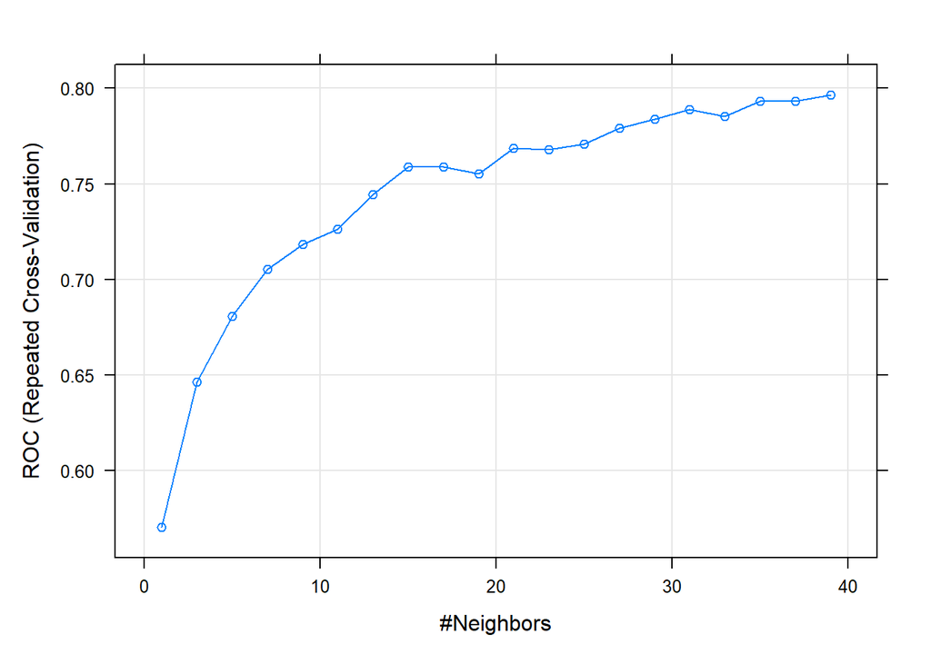

```r
plot(drugs_knn_train)
```

```r
k_value <- data.frame(k = 35)

set.seed(987654321)
drugs_knn_train_final <-
  train(consumption_cocaine_last_month ~ .,
        drugs_train,
        method = "knn",
        metric = "ROC",
        trControl = ctrl_cv5_knn,
        tuneGrid = k_value,
        preProcess = c("range"))

drugs_knn_train_final
```

```
## k-Nearest Neighbors
##
## 1100 samples
##   17 predictor
##    2 classes: 'No', 'Yes'
##
## Pre-processing: re-scaling to [0, 1] (49)
## Resampling: Cross-Validated (5 fold, repeated 3 times)
## Summary of sample sizes: 880, 880, 880, 880, 880, 880, ...
## Addtional sampling using up-sampling prior to pre-processing
##
## Resampling results:
##
##   ROC        Accuracy   Kappa      Sensitivity  Specificity  Pos Pred Value
##   0.7917783  0.6439385  0.1624928  0.6282121    0.8118908    0.9728668
##   Neg Pred Value  Precision  Recall     F1        Balanced Accuracy
##   0.1699136       0.9728668  0.6282121  0.763075  0.7200515
##
## Tuning parameter 'k' was held constant at a value of 35
```

The final model specifications are as follows:

```
##                                    Accuracy Sensitivity Specificity
## Training data                       0.64909     0.94681     0.62127
## Test data                           0.65500     0.87879     0.63488
## All data (test + training combined  0.64800     0.92913     0.62200
##                                    Pos Pred Value Neg Pred Value      F1
## Training data                             0.18936        0.99206 0.31560
## Test data                                 0.17791        0.98312 0.29592
## All data (test + training combined        0.18524        0.98957 0.30890
##                                    Balanced accuracy
## Training data                                0.78404
## Test data                                    0.75683
## All data (test + training combined           0.77556
```

We applied the final model on the test sample prepared by the teacher. Our expected results would be similar to the test subsample of the training sample that we analyzed above i.e. Balanced Accuracy of around 0.76.

# Regression - traffic dataset

## Data preparation

In the first step, we loaded the data. Then they were checked if any missing observations are present within the data. We also analyzed the structure and type of the variables.

```r
traffic_train=read.csv(file="traffic_train.csv",sep=",",header=TRUE)
traffic_test=read.csv(file="traffic_test.csv",sep=",",header=TRUE)
```

The first column - the date of observation with an accuracy of an hour was converted to the datetime data type.

Instead of using the index column, we created features describing each time characteristic: hour, month, year, yearweek (which might represent information about holidays), weekday, weekend and date.

Our train dataset covers the period between 2014-10-01 and 2018-12-31, consists of 1223 days, giving 29701 observations total.

The weather conditions are described by two variables: weather_general and weather_detailed. The detailed feature includes 37 levels which are very similar to the general variable levels. In addition, some of the levels are very small, which could affect the results’ bias. For this reason, we have decided not to use the weather_detailed characteristic, which should also reduce possible overfitting of the model.

```r
table(traffic_train$weather_detailed)
```

```
##
##                       broken clouds                             drizzle
##                                3130                                 337
##                          few clouds                                 fog
##                                1499                                 481
##                       freezing rain                                haze
##                                   2                                 743
##             heavy intensity drizzle                heavy intensity rain
##                                  31                                 287
##                          heavy snow             light intensity drizzle
##                                 581                                 551
##         light intensity shower rain                          light rain
##                                   8                                2248
##                 light rain and snow                   light shower snow
##                                   4                                   4
##                          light snow                                mist
##                                1046                                3491
##                       moderate rain                     overcast clouds
##                                 966                                3491
##               proximity shower rain              proximity thunderstorm
##                                  31                                 311
## proximity thunderstorm with drizzle    proximity thunderstorm with rain
##                                   8                                  19
##                    scattered clouds                      shower drizzle
##                                2044                                   1
##                         shower snow                        sky is clear
##                                   1                                8030
##                               sleet                               smoke
##                                   1                                  17
##                                snow                             squalls
##                                 157                                   4
##                        thunderstorm           thunderstorm with drizzle
##                                  58                                   2
##        thunderstorm with heavy rain     thunderstorm with light drizzle
##                                  42                                   2
##        thunderstorm with light rain              thunderstorm with rain
##                                  32                                  23
##                     very heavy rain
##                                  18
```

All variables which were stored as characters were converted to factors.

We also changed the type of the variable Year to numeric.

Most of the observations represented a good weather. However, we merged similar events: levels “Smoke” and “Haze” and “Squall” and “Thunderstorm”, which are usually very extreme weather events.

After checking the structure of the yearweek feature, we noticed that only a few observations were recorded in the last week of the year (no. 53), we combined this level with the no. 52.

We found one outlier in our traffic dataset - with the temperature below -200C. We decided to remove this observation, as it was most likely an error.

```r
out_temp <- which(traffic_train_train$temperature > -200)
traffic_train_train <- traffic_train_train[out_temp,]
```

## Feature engeneering

#### Box-Cox transformation

To transform our positively skewed dependent variable to a relatively symmetrical distribution, we used a Box-Cox transformation.

```r
traffic_boxcox <- boxcox(traffic_train_train$traffic +1, standardize = FALSE)
```

Our optimal lambda:

```
## [1] 0.6703624
```

We can compare the results of transformation below. Although the new distribution is not ideally symmetrical, the predictive power of our model should still improve.

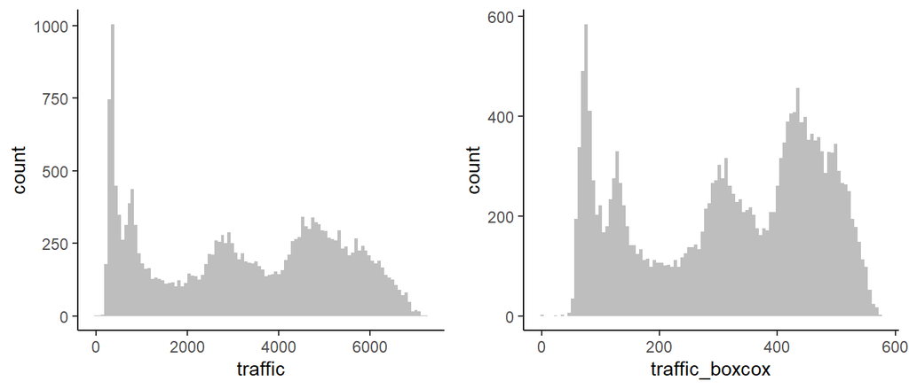

```r
g1 <- ggplot(traffic_train_train,aes(x = traffic)) + geom_histogram(fill="grey",bins=100) + theme_classic()
g2 <- ggplot(traffic_train_train,aes(x = traffic_boxcox)) + geom_histogram(fill="grey",bins=100) + theme_classic()
grid.arrange(g1,g2,ncol=2)
```

#### Features binning

We used the cut() function to divide the following variables into bigger groups: clouds_coverage_pct, months and time.

As for the clouds_coverage_pct, we divided the observations into groups based on their quantiles. The final intervals were as following: [0,1], (1,40], (40,75], (75,90], (90,100].

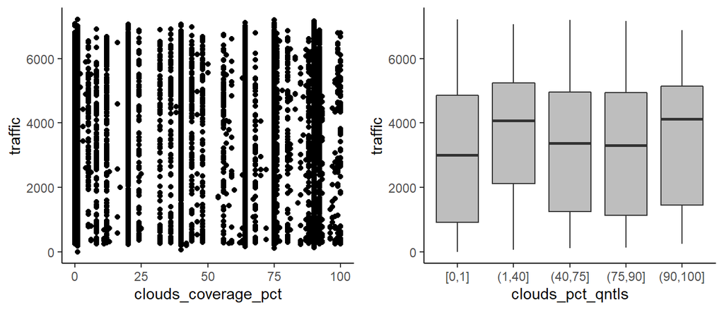

The feature Month was divided into the 4 natural seasons: spring, summer, fall and winter. We also checked if the months had similar traffic mean for each season.

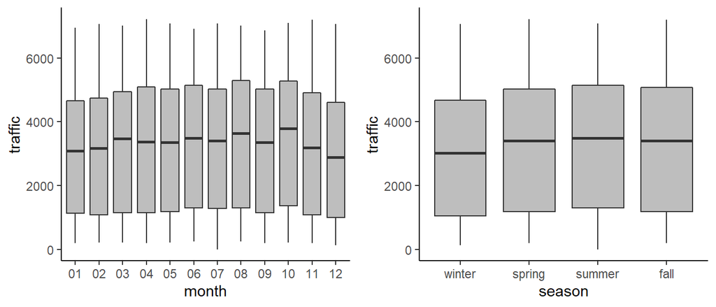

The binning of the time feature was based on the graph and mean traffic values analysis. We decided to create five levels: “morning”,“midday”,“afternoon”,“evening” and “night”, corresponding with the following hours: 6-10,11-14,15-17,18-21,22-5.

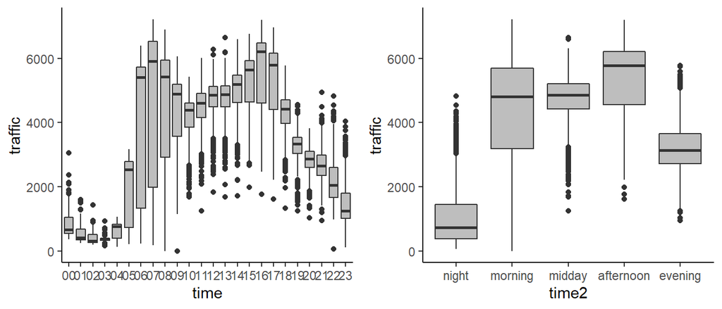

## Final model

The best results were estimated using a model with grouped features and a feature describing yearweeks (which probably represented the effect on holidays on traffic).

```r
selected3 <- c("weather_general2","clouds_pct_qntls", "temperature", "rain_mm",
               "time2", "season", "year", "weekend","traffic", "traffic_boxcox", "yearweek")
```

#### Time series cross-validation

Because traffic data set contains a time series data, we decided to use a time-based split for cross-validation. Using a “timeslice” method the test sample was divided into 5 slices, each containing 8 000 observations.

```r
options(contrasts = c("contr.treatment",  # for non-ordinal factors
                      "contr.treatment")) # for ordinal factors

myTimeControl <- trainControl(method = "timeslice",
                              initialWindow = 6000,
                              horizon = 2000,
                              fixedWindow = TRUE,
                              skip=3000)
```

#### KNN

During the process of model selection we run the linear models using different features, the KNN models with the k-parametr optimalization, and the LASSO and elastic Net model. The interpretation of the results was not straightforward. For MAPE, the KNN model turned out to be the most optimal. On the other hand, it achieved a small R2 as well as high absolute errors. If we took a different measure as selection criteria, then probably the linear model would be the optimal one.

For our KNN model, first We tried a very wide range of k values - from 1 to 150 (corresponding with a size of our data). In the second step we narrowed it and at the end we decided to keep the KNN model with k=8.

```r
different_k3b <- data.frame(k = seq(1,20, 1))

traffic_knn3b <-
  train(traffic_boxcox ~ .,
        data = traffic_var3_train %>%
          # we exclude traffic
          dplyr::select(-traffic)
        ,
        # model type - now knn!!
        method = "knn",
        # validation used!
        trControl = myTimeControl,
        # parameters to be compared
        tuneGrid = different_k3b,
        metric = "RMSE",
        preProcess = c("range"))

traffic_knn3b
```

```
## k-Nearest Neighbors
##
## 20369 samples
##     9 predictor
##
## Pre-processing: re-scaling to [0, 1] (75)
## Resampling: Rolling Forecasting Origin Resampling (2000 held-out with a fixed window)
## Summary of sample sizes: 6000, 6000, 6000, 6000, 6000
## Resampling results across tuning parameters:
##
##   k   RMSE       Rsquared   MAE
##    1  113.81298  0.4984339  81.12723
##    2  101.66699  0.5760791  73.87446
##    3   98.38179  0.5989389  71.64230
##    4   96.38177  0.6102690  71.23175
##    5   94.69104  0.6247007  71.02936
##    6   93.24638  0.6354502  70.81287
##    7   92.32992  0.6426080  70.62955
##    8   91.58298  0.6504155  70.55489
##    9   92.86504  0.6392235  72.18161
##   10   92.25393  0.6439020  72.08850
##   11   92.30066  0.6442777  72.49291
##   12   92.13545  0.6475864  72.75667
##   13   92.53339  0.6467386  73.52149
##   14   92.85244  0.6483330  74.30709
##   15   92.75254  0.6525122  74.54504
##   16   92.95847  0.6530886  74.68593
##   17   93.81924  0.6501564  75.58954
##   18   94.39260  0.6481358  76.21984
##   19   94.91477  0.6463836  76.64197
##   20   95.76789  0.6412225  77.47898
##
## RMSE was used to select the optimal model using the smallest value.
## The final value used for the model was k = 8.
```

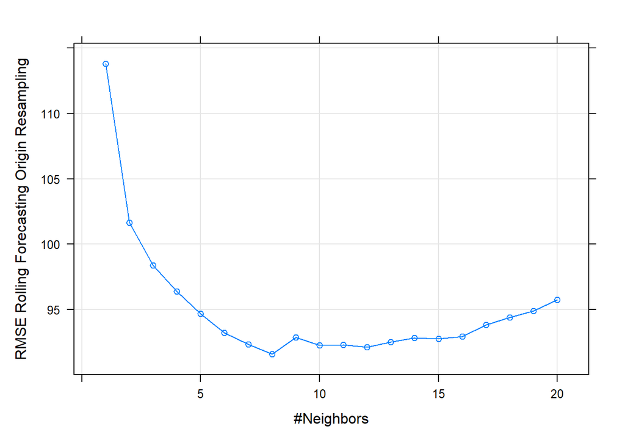

```
##               MSE     RMSE       MAE      MAPE        R2
## knn_train 1333050 1154.578  839.7655 0.6223464 0.6955796
## knn_test  1989179 1410.382 1061.1688 4.5160543 0.5026819
```

```r
plot(traffic_knn3b)
```

```r
final_k <- data.frame(k = 8)

traffic_bestModel <-
  train(traffic_boxcox ~ .,
        data = traffic_var3_train %>%
          # we exclude traffic
          dplyr::select(-traffic)
        ,
        # model type - now knn!!
        method = "knn",
        # validation used!
        trControl = myTimeControl,
        # parameters to be compared
        tuneGrid = final_k,
        metric = "RMSE",
        preProcess = c("range"))

traffic_bestModel
```

```
## k-Nearest Neighbors
##
## 20369 samples
##     9 predictor
##
## Pre-processing: re-scaling to [0, 1] (75)
## Resampling: Rolling Forecasting Origin Resampling (2000 held-out with a fixed window)
## Summary of sample sizes: 6000, 6000, 6000, 6000, 6000
## Resampling results:
##
##   RMSE      Rsquared   MAE
##   91.58298  0.6504155  70.55489
##
## Tuning parameter 'k' was held constant at a value of 8
```

The comparison between the predicted and real traffic values, for both the train and the test sample, is presented below:

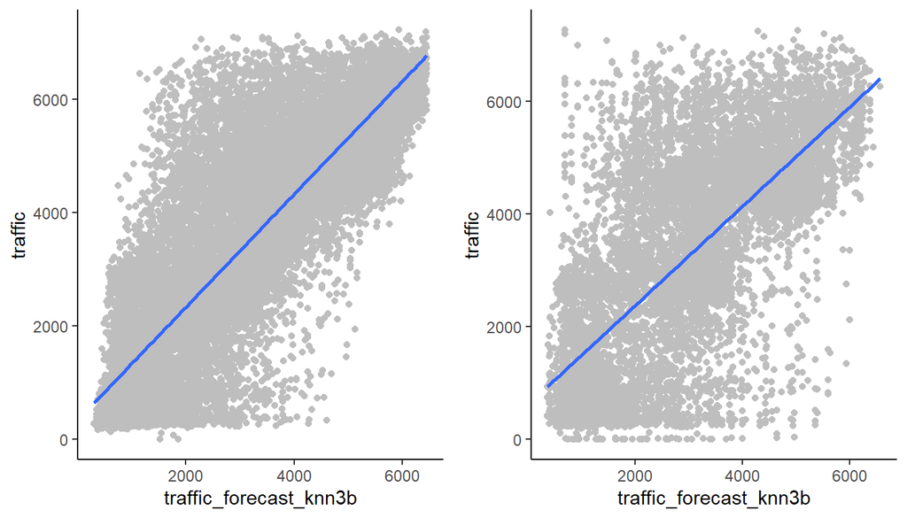

It is worth mentioning that the error measured on the test sample was much higher than on the the training data. Therefore we don’t expect the results to be very accurate, the MAPE will probably be close to 5.

Prediction:

```r
traffic_test$traffic_forecast <-(sapply(predict(traffic_knn3b,traffic_test), function(x){max(0,x)})*traffic_boxcox$lambda+1)^(1/traffic_boxcox$lambda)
```